# Pretrained Character Embeddings for Deep Learning and Automatic Text Generation

Max Woolf (@minimaxir)

2017-04-04

This R Notebook is the complement to my blog post [Pretrained Character Embeddings for Deep Learning and Automatic Text Generation](http://minimaxir.com/2017/04/char-embeddings/).

This notebook is licensed under the MIT License. If you use the code or data visualization designs contained within this notebook, it would be greatly appreciated if proper attribution is given back to this notebook and/or myself. Thanks! :)

```r
source("Rstart.R")
```

[output not shown]

```r
library(tsne)
```

# 1 Visualize GloVe Vectors

```r
df <- read_delim("glove.840B.300d-char.txt", col_names = F, delim=" ", quote = "—")
df[,1:6]
```

| X1 | X2 | X3 | X4 | X5 | X6 |
| --- | --- | --- | --- | --- | --- |
| $ | 0.144288 | -0.460809 | 0.205078 | 0.061188 | -0.057054 |
| ( | -0.045633 | 0.050699 | 0.183949 | 0.277213 | 0.311710 |
| , | 0.083794 | -0.471956 | 0.210845 | -0.198393 | -0.396052 |
| 0 | 0.177007 | -0.285789 | 0.262566 | -0.045959 | -0.305244 |
| 4 | 0.189158 | -0.297370 | 0.296691 | -0.023230 | -0.269874 |
| 8 | 0.146808 | -0.303080 | 0.273265 | -0.020310 | -0.271215 |
| < | 0.461110 | -0.384327 | 0.183889 | -0.122777 | 0.110410 |
| @ | 0.231718 | -0.187341 | 0.055388 | 0.135627 | -0.200797 |
| D | 0.233231 | -0.361018 | 0.085259 | -0.005739 | -0.093721 |
| H | 0.236003 | -0.317698 | 0.074001 | 0.015729 | -0.083927 |

[output cut: 84 more lines]

Assign colors by character type (warning: jank implementation for determining character type)

```r
type <- ifelse(df$X1 %in% letters, "lowercase",
          ifelse(df$X1 %in% LETTERS, "uppercase",
            ifelse(df$X1 %in% c(0:9), "numeric", "punctuation")))
type <- factor(type, levels=c("lowercase", "uppercase", "numeric", "punctuation"))
type
```

```
 [1] punctuation punctuation punctuation numeric     numeric
 [6] numeric     punctuation punctuation uppercase   uppercase
[11] uppercase   uppercase   uppercase   uppercase   punctuation
[16] punctuation lowercase   lowercase   lowercase   lowercase
[21] lowercase   lowercase   punctuation punctuation punctuation
[26] punctuation punctuation numeric     numeric     punctuation
[31] punctuation uppercase   uppercase   uppercase   uppercase
[36] uppercase   uppercase   punctuation punctuation lowercase
[41] lowercase   lowercase   lowercase   lowercase   lowercase
[46] punctuation punctuation punctuation punctuation punctuation
[51] numeric     numeric     punctuation punctuation uppercase
[56] uppercase   uppercase   uppercase   uppercase   uppercase
[61] uppercase   punctuation lowercase   lowercase   lowercase
[66] lowercase   lowercase   lowercase   lowercase   punctuation
[71] punctuation punctuation punctuation punctuation numeric
[76] numeric     numeric     punctuation uppercase   uppercase
[81] uppercase   uppercase   uppercase   uppercase   uppercase
[86] punctuation lowercase   lowercase   lowercase   lowercase
[91] lowercase   lowercase   lowercase   punctuation
Levels: lowercase uppercase numeric punctuation
```

```r
perplexity = 7
initial_dims = 16
max_iter = 5000
set.seed(123)
df_reduce <- tsne(df %>% select(X2:X301) %>% data.matrix(), perplexity = perplexity,
                  initial_dims = initial_dims, max_iter = max_iter)
```

[output not shown]

```r
df_reduce <- data.frame(char = df$X1, type = type, df_reduce) %>%
                tbl_df() %>%
                mutate(char = as.character(char))
df_reduce
```

| char | type | X1 | X2 |
| --- | --- | --- | --- |
| $ | punctuation | 200.515251 | 233.11824 |
| ( | punctuation | -173.581642 | 467.64697 |
| , | punctuation | 353.591189 | -427.33291 |
| 0 | numeric | 501.540846 | -363.64162 |
| 4 | numeric | 509.973877 | -429.83259 |
| 8 | numeric | 422.913751 | -421.57553 |
| < | punctuation | -347.480496 | 219.83406 |
| @ | punctuation | -267.010962 | -320.60761 |
| D | uppercase | 97.055364 | 310.59888 |
| H | uppercase | 151.059247 | 326.28190 |

[output cut: 84 more lines]

```r
plot <- ggplot(df_reduce, aes(x=X1, y=X2, label=char, color = type)) +
          geom_text(family="Source Code Pro Semibold") +
          theme_void(base_family = "Source Sans Pro", base_size=8) +
          scale_color_brewer(palette="Set1") +
          labs(title = "Projection of 300D GloVe Character Vectors into 2D Space (16D, perplexity = 7)",
               subtitle = "Characters closer to each other are more similar in usage context.",
               color = '') +
          theme(plot.margin = unit(c(0.2,0.2,0.2,0.2),"cm"),
                plot.subtitle = element_text(family="Open Sans Condensed Bold", size=8, color="#666666"))
max_save(plot, "char-tsne", w=5, h=4, "Stanford NLP")
```

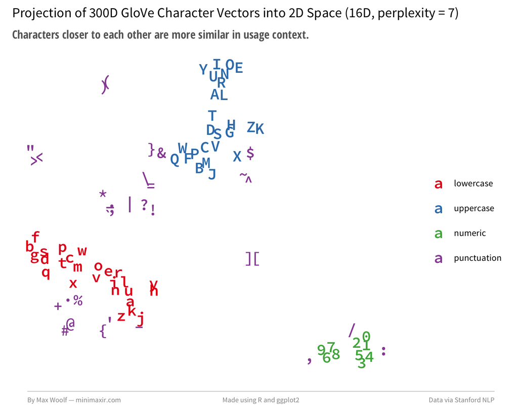

```r
perplexity = 2
initial_dims = 64
max_iter = 5000
set.seed(123)
df_reduce <- tsne(df %>% select(X2:X301) %>% data.matrix(), perplexity = perplexity,
                  initial_dims = initial_dims, max_iter = max_iter)
```

[output not shown]

```r
df_reduce <- data.frame(char = df$X1, type = type, df_reduce) %>%
                tbl_df() %>%
                mutate(char = as.character(char))
plot <- ggplot(df_reduce, aes(x=X1, y=X2, label=char, color = type)) +
          geom_text(family="Source Code Pro Semibold") +
          theme_void(base_family = "Source Sans Pro", base_size=8) +
          scale_color_brewer(palette="Set1") +
          labs(title = "Projection of 300D GloVe Character Vectors into 2D Space (64D, perplexity = 2)",
               subtitle = "Characters closer to each other are more similar in usage context.",
               color = '') +
          theme(plot.margin = unit(c(0.2,0.2,0.2,0.2),"cm"),
                plot.subtitle = element_text(family="Open Sans Condensed Bold", size=8, color="#666666"))
max_save(plot, "char-tsne-2", w=5, h=4, "Stanford NLP")
```

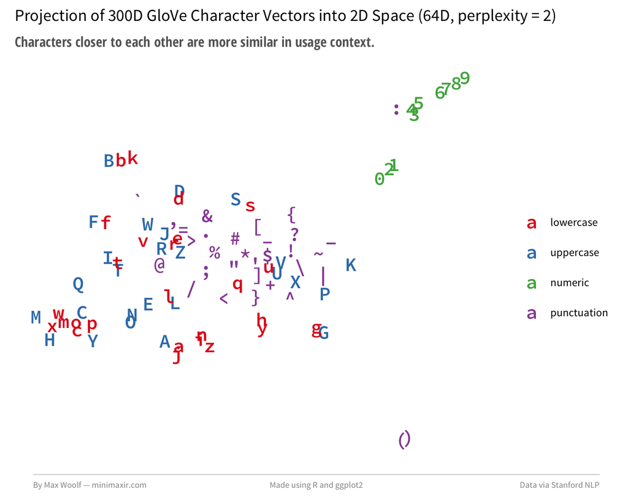

# 2 Visualize Embedded Magic Characters

```r
df_embed <- read_delim("char-embeddings.txt", col_names = F, delim=" ", quote = "—")
```

```
1 parsing failure.
row col    expected      actual                  file
 36  -- 301 columns 302 columns 'char-embeddings.txt'
```

```r
df_embed <- na.omit(df_embed)   # removes space and newline since will not parse
df_embed[,1:6]
```

| X1 | X2 | X3 | X4 | X5 | X6 |
| --- | --- | --- | --- | --- | --- |
| Y | 0.273228000 | -0.42274200 | 0.154817000 | 0.26070100 | -0.098025900 |
| F | 0.181323000 | -0.36758600 | -0.148974000 | 0.37599100 | -0.215051000 |
| d | 0.310747000 | -0.44868000 | -0.032982800 | 0.07261090 | -0.245013000 |
| N | 0.291162000 | -0.43437500 | -0.159023000 | 0.04314490 | 0.060887600 |
| h | -0.084843100 | 0.01730700 | 0.139856000 | 0.01884640 | 0.059662500 |
| ( | -0.119791000 | 0.38235500 | 0.259520000 | 0.43219000 | 0.468319000 |
| C | 0.104529000 | -0.49949900 | -0.101365000 | 0.24970800 | -0.302233000 |
| w | 0.080462000 | -0.27895000 | 0.054043900 | 0.16825000 | -0.004672340 |
| @ | 0.262143000 | 0.13347200 | -0.064186500 | 0.38306700 | -0.521202000 |
| V | 0.245919000 | -0.32016600 | 0.020574100 | 0.18089100 | -0.044160500 |

[output cut: 79 more lines]

```r
type_embed <- ifelse(df_embed$X1 %in% letters, "lowercase",
                ifelse(df_embed$X1 %in% LETTERS, "uppercase",
                 ifelse(df_embed$X1 %in% c(0:9), "numeric", "punctuation")))
type_embed <- factor(type_embed, levels=c("lowercase", "uppercase", "numeric", "punctuation"))
```

```r
perplexity = 10
initial_dims = 30
max_iter = 5000
set.seed(123)
df_reduce <- tsne(df_embed %>% select(X2:X301) %>% data.matrix(), perplexity = perplexity,
                  initial_dims = initial_dims, max_iter = max_iter)
```

[output not shown]

```r
df_reduce <- data.frame(char = df_embed$X1, type = type_embed, df_reduce) %>%
                tbl_df() %>%
                mutate(char = as.character(char))
plot <- ggplot(df_reduce, aes(x=X1, y=X2, label=char, color = type)) +
          geom_text(family="Source Code Pro Semibold") +
          theme_void(base_family = "Source Sans Pro", base_size=8) +
          scale_color_brewer(palette="Set1") +
          labs(title = "Projection of 300D Magic Card Character Vectors into 2D Space (30D, perplexity = 10)",
               subtitle = "Characters closer to each other are more similar in usage context.",
               color = '') +
          theme(plot.margin = unit(c(0.2,0.2,0.2,0.2),"cm"),
                plot.subtitle = element_text(family="Open Sans Condensed Bold", size=8, color="#666666"))
max_save(plot, "char-tsne-embed", w=5, h=4, "Keras Logging")
```

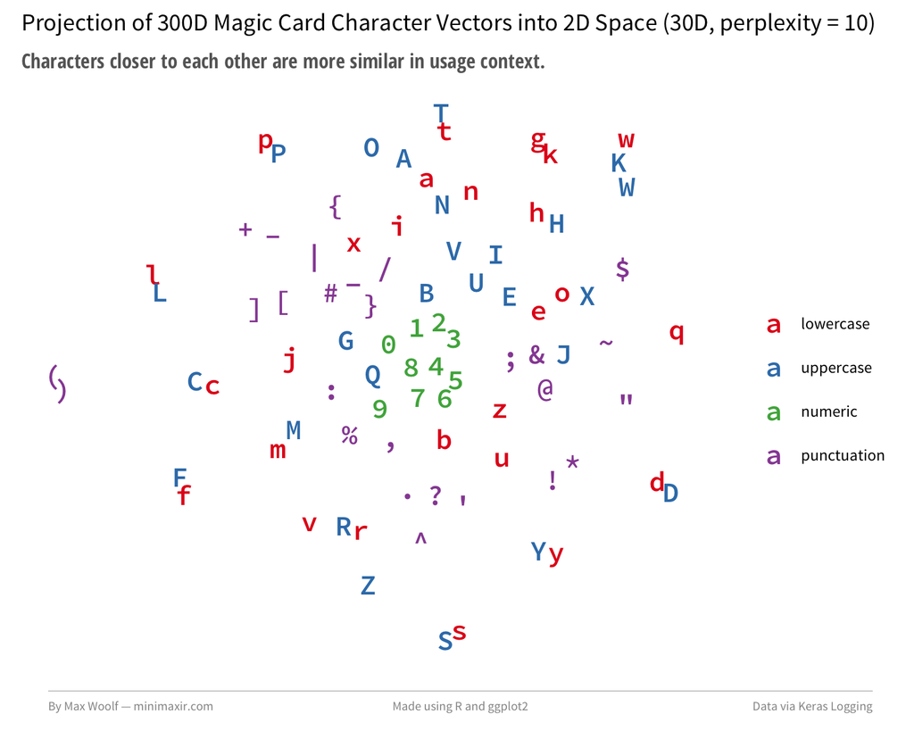

# 3 Training Perfomance

```r
batches_per_epoch = 7850
df_train <- read_csv("log.csv") %>% filter(iteration <= 20) %>%
              mutate(cumbatch = (iteration-1) * batches_per_epoch + batch)
df_train %>% head(200)
```

| iteration | batch | batch_loss | epoch_loss | elapsed_time | cumbatch |
| --- | --- | --- | --- | --- | --- |
| 1 | 0 | 4.941630 | 4.941630 | 1.76 | 0 |
| 1 | 50 | 2.590570 | 3.260140 | 5.81 | 50 |
| 1 | 100 | 2.214620 | 2.838710 | 9.78 | 100 |
| 1 | 150 | 2.171440 | 2.611620 | 13.74 | 150 |
| 1 | 200 | 1.796990 | 2.441630 | 17.66 | 200 |
| 1 | 250 | 1.801850 | 2.313130 | 21.55 | 250 |
| 1 | 300 | 1.461610 | 2.211690 | 25.43 | 300 |
| 1 | 350 | 1.463440 | 2.127590 | 29.34 | 350 |
| 1 | 400 | 1.599150 | 2.060650 | 33.22 | 400 |
| 1 | 450 | 1.772700 | 2.003490 | 37.16 | 450 |

[output cut: 190 more lines]

```r
#df_train_reshape <- df_train %>% gather(key = loss_type, value = loss, batch_loss, epoch_loss) %>%
#                      mutate(loss_type = factor(loss_type))
#df_train_reshape %>% head(100)
```

```r
plot <- ggplot(df_train, aes(x=cumbatch, y=batch_loss, color=factor(iteration))) +
          geom_line(size=0.1) +
          scale_y_sqrt(breaks=c(0, 0.25, 0.5, 1, 2, 4)) +
          scale_x_continuous(breaks = seq(0, max(df_train$cumbatch)+batches_per_epoch, by=batches_per_epoch), labels = c(0:20)) +
          fte_theme() +
          theme(panel.grid.major = element_line(size=0.1)) +
    labs(title = "Batch Loss Over Time While Training Magic Card Generator",
          x = "# Epoch",
          y = "Batch Loss (128 Samples per Batch)")
max_save(plot, "batch-losses", "Keras Logging")
```

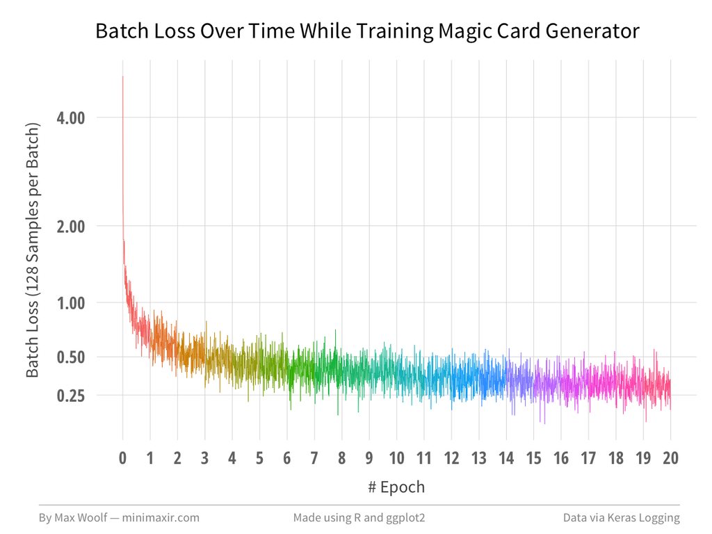

```r
plot <- ggplot(df_train, aes(x=cumbatch, y=epoch_loss, color=factor(iteration))) +
          geom_line(size=0.5) +
          scale_y_sqrt(breaks=c(0, 0.25, 0.5, 1, 2, 4)) +
          scale_x_continuous(breaks = seq(0, max(df_train$cumbatch)+batches_per_epoch, by=batches_per_epoch), labels = c(0:20)) +
          fte_theme() +
          theme(panel.grid.major = element_line(size=0.1)) +
    labs(title = "Epoch Loss Over Time While Training Magic Card Generator",
          x = "# Epoch",
          y = "Epoch Loss (Average Batch Loss During Epoch)")
max_save(plot, "epoch-losses", "Keras Logging")
```

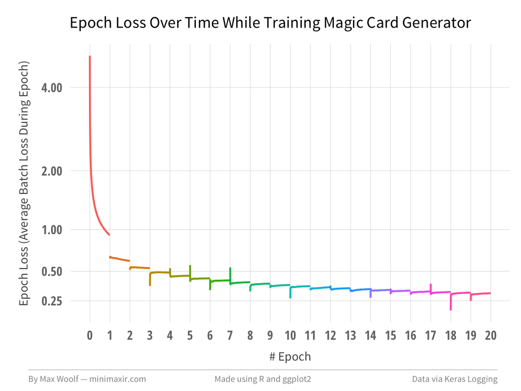

# 4 LICENSE

The MIT License (MIT)

Copyright (c) 2017 Max Woolf

Permission is hereby granted, free of charge, to any person obtaining a copy of this software and associated documentation files (the “Software”), to deal in the Software without restriction, including without limitation the rights to use, copy, modify, merge, publish, distribute, sublicense, and/or sell copies of the Software, and to permit persons to whom the Software is furnished to do so, subject to the following conditions:

The above copyright notice and this permission notice shall be included in all copies or substantial portions of the Software.

THE SOFTWARE IS PROVIDED “AS IS”, WITHOUT WARRANTY OF ANY KIND, EXPRESS OR IMPLIED, INCLUDING BUT NOT LIMITED TO THE WARRANTIES OF MERCHANTABILITY, FITNESS FOR A PARTICULAR PURPOSE AND NONINFRINGEMENT. IN NO EVENT SHALL THE AUTHORS OR COPYRIGHT HOLDERS BE LIABLE FOR ANY CLAIM, DAMAGES OR OTHER LIABILITY, WHETHER IN AN ACTION OF CONTRACT, TORT OR OTHERWISE, ARISING FROM, OUT OF OR IN CONNECTION WITH THE SOFTWARE OR THE USE OR OTHER DEALINGS IN THE SOFTWARE.